# 3次元エビデンス分析ダッシュボード

2026年09月12日 12:35

## 📊 3次元エビデンス分析ダッシュボード

**分析変数**: Dept × Gender × Admit (応答変数: Admit) | **総度数**: N = 4,526 | **最良モデル(BIC)**: M5 | **全体効果量 (Cramér’s V)**: 0.4170 | **run-id**: ucb_admit_standard

#### 🔑 変数定義と因子記号の対応凡例

- A **Dept**
- B **Gender**
- C **Admit**応答変数

※ カテゴリの水準名と、分析上の因子記号（A, B, C）は異なります。以降のモデル構造や数式は本凡例の因子記号に基づきます。

M5

Deptで層別したとき、GenderとAdmitは条件付き独立である (`[AB][AC]`)

候補 9 モデル中 BIC 最小 | ※ 相対的採択であり、真の独立や因果関係を証明するものではありません

明示式BIC: **332.31**

次点 (M8): **ΔBIC +6.89**

🧠 AI エグゼクティブ・サマリー（Pass 2 専門的考察）

# UCB Admissions 3次元対数線形分析 エグゼクティブサマリー

## 1. 今回分かったこと（非専門家向け要約）

1. **学部による合格率構造の違い（シンプソンのパラドックス）**: 全体の志願者を学部（`Dept`）で層別して分析した結果、合否（`Admit`）と性別（`Gender`）の関連は、どの学部に志願したかという構成差に強く依存していることが判明しました。
2. **条件付き独立性の支持**: 比較した9つの階層モデルの中で、「学部で層別すると性別と合否は条件付き独立である」とするモデル（M5）がデータに最も適合しました。 例えば学部 A においては、男性の合格率は観測度数 512/825人（生割合: 62.06%、Dirichlet事後平均: 62.04%）、女性の合格率は観測度数 89/108人（生割合: 82.41%）であり、むしろ女性の合格率の方が高い傾向（男女差事後平均: -0.1976）が見られます。
3. **因果関係や性差不存在への飛躍の禁止**: この結果は「大学院入試全体において性差が完全に存在しないこと」や「性別が合否に因果的影響を及ぼさないこと」を証明するものではありません。各学部の志願倍率や選考基準の違いを考慮した関連構造の記述的モデル選択です。

## 3. 解釈上の留保と次の確認事項

1. **相対的モデル選択の限界**: BIC 最小による M5 の採択は、検討した 9 つのポアソン対数線形候補モデル間での相対的優位性を示すものであり、真のデータ生成過程を完全に特定したわけではありません。
2. **M5 基準における隔離セル（QUARANTINED）の存在**: M5 基準では期待度数小または高レバレッジにより 11セルが QUARANTINED に分類されています。一部の小規模学部における数値的不安定性には留意が必要です。
3. **公平性・実務判断への拡張禁止**: 合否判定の妥当性や公平性の判断には、志願者の学歴、専攻適性、試験得点等の交絡要因を追加した確証的因果推論が必要です。本結果を単独で実務的合否判断や差別認定に用いてはなりません。

📈 条件付き割合と事後不確実性（Dirichlet推論）

**注目割合**:

```
P(Admit = Admitted | Dept,
Gender)
```

（分母: Admitted, Rejected の和, 95% 等裾信用区間 ETI）

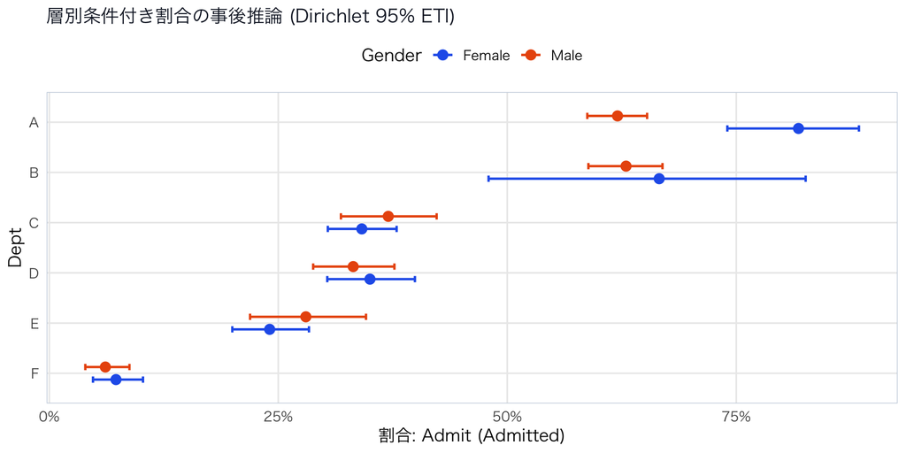

| 層別水準 | 比較水準 | 分子度数 | 分母度数 | 生割合 | 事後平均 | 95%CI下限 | 95%CI上限 |
| --- | --- | --- | --- | --- | --- | --- | --- |
| A | Male | 512 | 825 | 0.6206 | 0.6204 | 0.5874 | 0.6527 |
| A | Female | 89 | 108 | 0.8241 | 0.818 | 0.7403 | 0.884 |
| B | Male | 353 | 560 | 0.6304 | 0.6297 | 0.5886 | 0.6695 |
| B | Female | 17 | 25 | 0.68 | 0.6659 | 0.4796 | 0.8258 |
| C | Male | 120 | 325 | 0.3692 | 0.3701 | 0.3184 | 0.4229 |
| C | Female | 202 | 593 | 0.3406 | 0.3412 | 0.3041 | 0.3792 |
| D | Male | 138 | 417 | 0.3309 | 0.3318 | 0.2881 | 0.3768 |
| D | Female | 131 | 375 | 0.3493 | 0.3501 | 0.3035 | 0.3992 |
| E | Male | 53 | 191 | 0.2775 | 0.2801 | 0.2192 | 0.3458 |
| E | Female | 94 | 393 | 0.2392 | 0.2406 | 0.1998 | 0.2835 |

[output cut: 2 more lines]

⚗ 対数線形モデル比較（総度数 N 基準の明示式BIC）

※ *L*: ポアソン完全尤度, *p*: 推定パラメータ数（切片含む）, *N*: 総度数（本解析: 4,526, ln *N* = 8.4176）。**値が小さいほど好ましい**。  
※ **相対評価の原則**: 最良モデルは候補集合における相対的採択であり、真の因果関係を証明するものではありません。

| モデルと仮定 | 生成クラス | 残差自由度 | 逸脱度 | BIC | ΔBIC |
| --- | --- | --- | --- | --- | --- |
| M5: Deptで層別したとき、GenderとAdmitは条件付き独立である 数式・定義 | [AB][AC] | 6 | 21.7355 | 332.3119 | 0 |
| M8: 全2因子交互作用を含み、3因子交互作用を含まない（均一連関） 数式・定義 | [AB][AC][BC] | 5 | 20.2043 | 339.1982 | 6.886300000000006 |
| M9: 飽和モデル（3因子交互作用まで含む） 数式・定義 | [ABC] | 0 | 0 | 361.0819 | 28.77000000000004 |
| M6: Genderで層別したとき、DeptとAdmitは条件付き独立である 数式・定義 | [AB][BC] | 10 | 783.607 | 1060.513 | 728.2011 |
| M2: (Dept, Gender) と Admit は結合独立である 数式・定義 | [AB][C] | 11 | 877.0564 | 1145.5448 | 813.2329 |
| M7: Admitで層別したとき、DeptとGenderは条件付き独立である 数式・定義 | [AC][BC] | 10 | 1148.9009 | 1425.8069 | 1093.495 |
| M3: (Dept, Admit) と Gender は結合独立である 数式・定義 | [AC][B] | 11 | 1242.3503 | 1510.8387 | 1178.5268 |
| M4: (Gender, Admit) と Dept は結合独立である 数式・定義 | [BC][A] | 15 | 2004.2218 | 2239.0398 | 1906.7279 |
| M1: 3因子が相互に独立である 数式・定義 | [A][B][C] | 16 | 2097.6712 | 2324.0717 | 1991.7598 |

#### 🔍 各候補モデルの数理定義・構造仮定詳細

**M1: [A][B][C]**開閉**

##### モデル M1 の数理定義と構造仮定

**生成クラス（ブラケット記法）**: `[A][B][C]` | **実変数展開**: `[Dept][Gender][Admit]`

**独立性仮定**: 3因子が相互に独立である

**適合 formula (R)**: `Freq ~ Dept + Gender + Admit`

残差自由度: 16 | 逸脱度: 2097.67 | BIC: 2324.07 | ΔBIC: 1991.76

**M2: [AB][C]**開閉**

##### モデル M2 の数理定義と構造仮定

**生成クラス（ブラケット記法）**: `[AB][C]` | **実変数展開**: `[Dept, Gender][Admit]`

**独立性仮定**: (Dept, Gender) と Admit は結合独立である

**適合 formula (R)**: `Freq ~ Dept * Gender + Admit`

残差自由度: 11 | 逸脱度: 877.06 | BIC: 1145.54 | ΔBIC: 813.23

**M3: [AC][B]**開閉**

##### モデル M3 の数理定義と構造仮定

**生成クラス（ブラケット記法）**: `[AC][B]` | **実変数展開**: `[Dept, Admit][Gender]`

**独立性仮定**: (Dept, Admit) と Gender は結合独立である

**適合 formula (R)**: `Freq ~ Dept * Admit + Gender`

残差自由度: 11 | 逸脱度: 1242.35 | BIC: 1510.84 | ΔBIC: 1178.53

**M4: [BC][A]**開閉**

##### モデル M4 の数理定義と構造仮定

**生成クラス（ブラケット記法）**: `[BC][A]` | **実変数展開**: `[Gender, Admit][Dept]`

**独立性仮定**: (Gender, Admit) と Dept は結合独立である

**適合 formula (R)**: `Freq ~ Gender * Admit + Dept`

残差自由度: 15 | 逸脱度: 2004.22 | BIC: 2239.04 | ΔBIC: 1906.73

**M5: [AB][AC] 最良モデル (BIC最小)**開閉**

##### モデル M5 の数理定義と構造仮定

**生成クラス（ブラケット記法）**: `[AB][AC]` | **実変数展開**: `[Dept, Gender][Dept, Admit]`

**独立性仮定**: Deptで層別したとき、GenderとAdmitは条件付き独立である

**適合 formula (R)**:

```
 Freq ~ Dept * Gender + Dept *
Admit
```

残差自由度: 6 | 逸脱度: 21.74 | BIC: 332.31 | ΔBIC: 0.00

**M6: [AB][BC]**開閉**

##### モデル M6 の数理定義と構造仮定

**生成クラス（ブラケット記法）**: `[AB][BC]` | **実変数展開**: `[Dept, Gender][Gender, Admit]`

**独立性仮定**: Genderで層別したとき、DeptとAdmitは条件付き独立である

**適合 formula (R)**:

```
 Freq ~ Dept * Gender + Gender
* Admit
```

残差自由度: 10 | 逸脱度: 783.61 | BIC: 1060.51 | ΔBIC: 728.20

**M7: [AC][BC]**開閉**

##### モデル M7 の数理定義と構造仮定

**生成クラス（ブラケット記法）**: `[AC][BC]` | **実変数展開**: `[Dept, Admit][Gender, Admit]`

**独立性仮定**: Admitで層別したとき、DeptとGenderは条件付き独立である

**適合 formula (R)**:

```
 Freq ~ Dept * Admit + Gender *
Admit
```

残差自由度: 10 | 逸脱度: 1148.90 | BIC: 1425.81 | ΔBIC: 1093.50

**M8: [AB][AC][BC]**開閉**

##### モデル M8 の数理定義と構造仮定

**生成クラス（ブラケット記法）**: `[AB][AC][BC]` | **実変数展開**:

```
 [Dept, Gender][Dept,
Admit][Gender, Admit]
```

**独立性仮定**: 全2因子交互作用を含み、3因子交互作用を含まない（均一連関）

**適合 formula (R)**:

```
 Freq ~ Dept * Gender + Dept *
Admit + Gender * Admit
```

残差自由度: 5 | 逸脱度: 20.20 | BIC: 339.20 | ΔBIC: 6.89

**M9: [ABC]**開閉**

##### モデル M9 の数理定義と構造仮定

**生成クラス（ブラケット記法）**: `[ABC]` | **実変数展開**: `[Dept, Gender, Admit]`

**独立性仮定**: 飽和モデル（3因子交互作用まで含む）

**適合 formula (R)**: `Freq ~ Dept * Gender * Admit`

残差自由度: 0 | 逸脱度: 0.00 | BIC: 361.08 | ΔBIC: 28.77

🎯 局所セル診断（基準モデル別残差・4軸診断フレームワーク）

セル診断は基準仮説に応じて異なる問いに答えます。**M1基準**（相互独立からの乖離）と**M5基準**（選択モデルからの残余乖離）をタブで切り替えて確認できます。  
※ 基準モデルごとに前提が異なるため、両者を合算した単一のエビデンス率は定義されません。

#### 「3因子が相互に独立である」という仮説（M1）からの局所的乖離の評価

24 / 24

評価対象セル

24 / 24

安定セル (100.0% REGULAR)

0 / 24

隔離セル (0.0% QUARANTINED)

12 / 24

探索候補セル (50.0%)

N = 4,526

総観測度数

**大標本 Dual-Filter 探索基準**:

```
|log(O/E)| ≥
0.50
```

かつ `Score統計量 T ≥ 3.84` かつ `REGULAR`。  
※ 探索候補件数は実務的重要性やセル合否の自動断定ではなく、多重性を考慮した重点探索の対象を示します。

🏆 効果比 |log(O/E)| 上位 10 セル

| Dept | Gender | Admit | 度数(O) | 期待値(E) | ピアソン残差 | 効果比:log(O/E) | 標準化差 | Score統計量(T) | P値 | 対数P値 | Leverage(h) | 診断状態 |
| --- | --- | --- | --- | --- | --- | --- | --- | --- | --- | --- | --- | --- |
| B | Female | Rejected | 8 | 145.2109 | -11.3865 | -2.8987 | -0.1693 | 189.4383 | 4.216e-43 | -97.57 | 0.3156 | REGULAR |
| A | Female | Rejected | 19 | 231.5928 | -13.9697 | -2.5005 | -0.2076 | 302.8764 | 7.782e-68 | -154.52 | 0.3557 | REGULAR |
| F | Male | Admitted | 22 | 164.6114 | -11.1154 | -2.0125 | -0.1652 | 179.7829 | 5.405e-41 | -92.72 | 0.3128 | REGULAR |
| B | Female | Admitted | 17 | 91.9687 | -7.8174 | -1.6882 | -0.1162 | 78.2571 | 9.046e-19 | -41.55 | 0.2191 | REGULAR |
| F | Female | Admitted | 24 | 112.249 | -8.3295 | -1.5427 | -0.1238 | 90.4264 | 1.92e-21 | -47.7 | 0.2327 | REGULAR |
| B | Male | Admitted | 353 | 134.8707 | 18.7826 | 0.9622 | 0.2792 | 502.4867 | 2.735e-111 | -254.58 | 0.2979 | REGULAR |
| E | Male | Admitted | 53 | 134.6401 | -7.0358 | -0.9323 | -0.1046 | 70.4974 | 4.609e-17 | -37.62 | 0.2978 | REGULAR |
| A | Male | Admitted | 512 | 215.1015 | 20.2435 | 0.8672 | 0.3009 | 619.0289 | 1.216e-136 | -312.96 | 0.338 | REGULAR |
| E | Female | Rejected | 299 | 144.9627 | 12.7937 | 0.724 | 0.1902 | 239.1163 | 6.129e-54 | -122.53 | 0.3155 | REGULAR |
| F | Female | Rejected | 317 | 177.2318 | 10.4987 | 0.5814 | 0.1561 | 164.6238 | 1.105e-37 | -85.1 | 0.3305 | REGULAR |

**📋 全 24 セル 4軸診断テーブル（クリックで展開）**

| Dept | Gender | Admit | 度数(O) | 期待値(E) | ピアソン残差 | 効果比:log(O/E) | 標準化差 | Score統計量(T) | P値 | 対数P値 | Leverage(h) | 診断状態 |
| --- | --- | --- | --- | --- | --- | --- | --- | --- | --- | --- | --- | --- |
| B | Female | Rejected | 8 | 145.2109 | -11.3865 | -2.8987 | -0.1693 | 189.4383 | 4.216e-43 | -97.57 | 0.3156 | REGULAR |
| A | Female | Rejected | 19 | 231.5928 | -13.9697 | -2.5005 | -0.2076 | 302.8764 | 7.782e-68 | -154.52 | 0.3557 | REGULAR |
| F | Male | Admitted | 22 | 164.6114 | -11.1154 | -2.0125 | -0.1652 | 179.7829 | 5.405e-41 | -92.72 | 0.3128 | REGULAR |
| B | Female | Admitted | 17 | 91.9687 | -7.8174 | -1.6882 | -0.1162 | 78.2571 | 9.046e-19 | -41.55 | 0.2191 | REGULAR |
| F | Female | Admitted | 24 | 112.249 | -8.3295 | -1.5427 | -0.1238 | 90.4264 | 1.92e-21 | -47.7 | 0.2327 | REGULAR |
| B | Male | Admitted | 353 | 134.8707 | 18.7826 | 0.9622 | 0.2792 | 502.4867 | 2.735e-111 | -254.58 | 0.2979 | REGULAR |
| E | Male | Admitted | 53 | 134.6401 | -7.0358 | -0.9323 | -0.1046 | 70.4974 | 4.609e-17 | -37.62 | 0.2978 | REGULAR |
| A | Male | Admitted | 512 | 215.1015 | 20.2435 | 0.8672 | 0.3009 | 619.0289 | 1.216e-136 | -312.96 | 0.338 | REGULAR |
| E | Female | Rejected | 299 | 144.9627 | 12.7937 | 0.724 | 0.1902 | 239.1163 | 6.129e-54 | -122.53 | 0.3155 | REGULAR |
| F | Female | Rejected | 317 | 177.2318 | 10.4987 | 0.5814 | 0.1561 | 164.6238 | 1.105e-37 | -85.1 | 0.3305 | REGULAR |

[output cut: 14 more lines]

**📋 旧指標監査（Evidence Score = r² − k·log N）: 正値 19 / 24 セル (79.2%)**

#### 「Deptで層別したとき、GenderとAdmitは条件付き独立である」という仮説（M5）からの局所的乖離の評価

24 / 24

評価対象セル

13 / 24

安定セル (54.2% REGULAR)

11 / 24

隔離セル (45.8% QUARANTINED)

1 / 24

探索候補セル (4.2%)

N = 4,526

総観測度数

**大標本 Dual-Filter 探索基準**:

```
|log(O/E)| ≥
0.50
```

かつ `Score統計量 T ≥ 3.84` かつ `REGULAR`。  
※ 探索候補件数は実務的重要性やセル合否の自動断定ではなく、多重性を考慮した重点探索の対象を示します。

🏆 効果比 |log(O/E)| 上位 10 セル

| Dept | Gender | Admit | 度数(O) | 期待値(E) | ピアソン残差 | 効果比:log(O/E) | 標準化差 | Score統計量(T) | P値 | 対数P値 | Leverage(h) | 診断状態 |
| --- | --- | --- | --- | --- | --- | --- | --- | --- | --- | --- | --- | --- |
| A | Female | Rejected | 19 | 38.4309 | -3.1344 | -0.7044 | -0.0466 | 17.248 | 0 | -10.32 | 0.4304 | REGULAR |
| A | Female | Admitted | 89 | 69.5691 | 2.3296 | 0.2463 | 0.0346 | 17.248 | 0 | -10.32 | 0.6853 | REGULAR |
| B | Female | Rejected | 8 | 9.188 | -0.3919 | -0.1385 | -0.0058 | 0.2537 | 0.6145 | -0.49 | 0.3946 | REGULAR |
| E | Male | Admitted | 53 | 48.0771 | 0.71 | 0.0975 | 0.0106 | 1.0011 | 0.3171 | -1.15 | 0.4964 | REGULAR |
| F | Female | Admitted | 24 | 21.9692 | 0.4333 | 0.0884 | 0.0064 | 0.3841 | 0.5354 | -0.62 | 0.5112 | REGULAR |
| F | Male | Admitted | 22 | 24.0308 | -0.4143 | -0.0883 | -0.0062 | 0.3841 | 0.5354 | -0.62 | 0.5532 | REGULAR |
| B | Female | Admitted | 17 | 15.812 | 0.2988 | 0.0724 | 0.0044 | 0.2537 | 0.6145 | -0.49 | 0.6482 | REGULAR |
| A | Male | Rejected | 313 | 293.5691 | 1.1341 | 0.0641 | 0.0169 | 17.2479 | 0 | -10.32 | 0.9254 | QUARANTINED |
| C | Male | Admitted | 120 | 113.9978 | 0.5622 | 0.0513 | 0.0084 | 0.7535 | 0.3854 | -0.95 | 0.5806 | REGULAR |
| E | Female | Admitted | 94 | 98.9229 | -0.495 | -0.051 | -0.0074 | 1.0011 | 0.3171 | -1.15 | 0.7553 | REGULAR |

**📋 全 24 セル 4軸診断テーブル（クリックで展開）**

| Dept | Gender | Admit | 度数(O) | 期待値(E) | ピアソン残差 | 効果比:log(O/E) | 標準化差 | Score統計量(T) | P値 | 対数P値 | Leverage(h) | 診断状態 |
| --- | --- | --- | --- | --- | --- | --- | --- | --- | --- | --- | --- | --- |
| A | Female | Rejected | 19 | 38.4309 | -3.1344 | -0.7044 | -0.0466 | 17.248 | 0 | -10.32 | 0.4304 | REGULAR |
| A | Female | Admitted | 89 | 69.5691 | 2.3296 | 0.2463 | 0.0346 | 17.248 | 0 | -10.32 | 0.6853 | REGULAR |
| B | Female | Rejected | 8 | 9.188 | -0.3919 | -0.1385 | -0.0058 | 0.2537 | 0.6145 | -0.49 | 0.3946 | REGULAR |
| E | Male | Admitted | 53 | 48.0771 | 0.71 | 0.0975 | 0.0106 | 1.0011 | 0.3171 | -1.15 | 0.4964 | REGULAR |
| F | Female | Admitted | 24 | 21.9692 | 0.4333 | 0.0884 | 0.0064 | 0.3841 | 0.5354 | -0.62 | 0.5112 | REGULAR |
| F | Male | Admitted | 22 | 24.0308 | -0.4143 | -0.0883 | -0.0062 | 0.3841 | 0.5354 | -0.62 | 0.5532 | REGULAR |
| B | Female | Admitted | 17 | 15.812 | 0.2988 | 0.0724 | 0.0044 | 0.2537 | 0.6145 | -0.49 | 0.6482 | REGULAR |
| A | Male | Rejected | 313 | 293.5691 | 1.1341 | 0.0641 | 0.0169 | 17.2479 | 0 | -10.32 | 0.9254 | QUARANTINED |
| C | Male | Admitted | 120 | 113.9978 | 0.5622 | 0.0513 | 0.0084 | 0.7535 | 0.3854 | -0.95 | 0.5806 | REGULAR |
| E | Female | Admitted | 94 | 98.9229 | -0.495 | -0.051 | -0.0074 | 1.0011 | 0.3171 | -1.15 | 0.7553 | REGULAR |

[output cut: 14 more lines]

**📋 旧指標監査（Evidence Score = r² − k·log N）: 正値 1 / 24 セル (4.2%)**

**📚 統計指標の解説：4軸セル診断フレームワーク（クリックで展開）**

### 2. 大標本 Dual-Filter 原則

総度数 $N > 2{,}000$ の大標本下では、以下の二段階判定（Dual-Filter）を厳格に適用します：

Generated by **vcd-bayesian-evidence-analysis (4-Axis Multi-Baseline Canonical)** | Rao’s Score Statistic & Explicit BIC (N) | 完全オフライン静的HTML (KaTeX) | 2026-09-12 12:35 JST